# R Visualizacion Basico

## Sistemas de Coordenadas

Los sistemas de coordenadas son probablemente la parte más complicada de ggplot2. El sistema predeterminado es el sistema de coordenadas cartesianas, donde las posiciones x e y actúan independientemente para determinar la ubicación de cada punto. Hay varios otros sistemas de coordenadas que ocasionalmente son útiles.

- coord_flip(): cambia ejes x y.Esto es útil, por ejemplo, si quieres diagramas de caja horizontales. También es útil para etiquetas largas

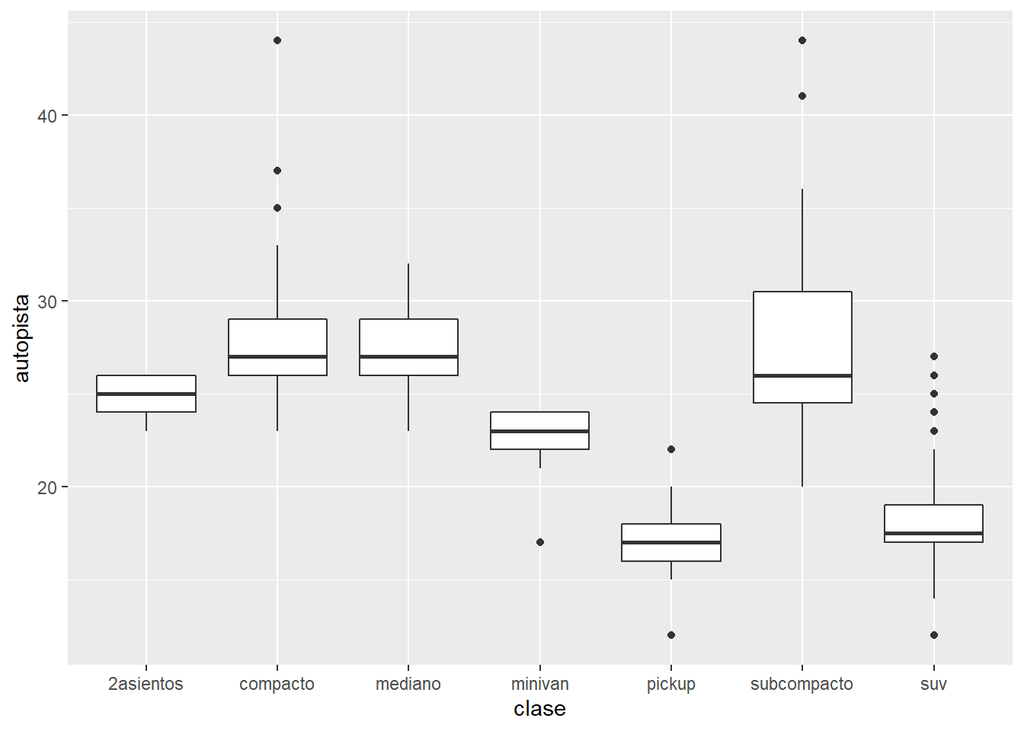

```r
ggplot(data = millas, mapping = aes(x = clase, y = autopista)) +
  geom_boxplot()
```

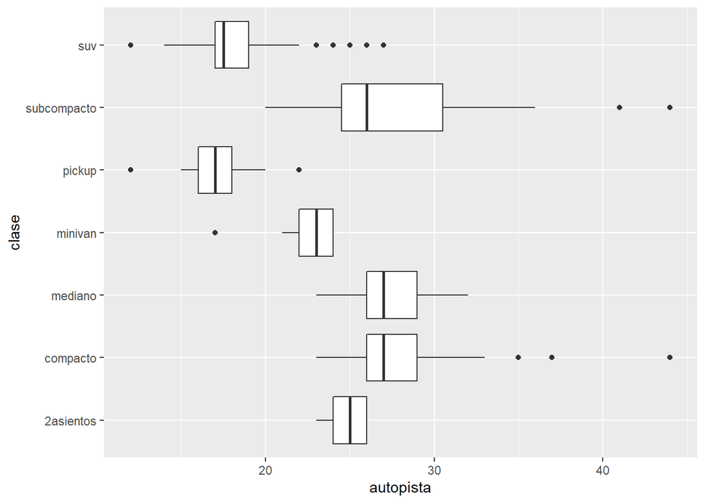

```r
ggplot(data = millas, mapping = aes(x = clase, y = autopista)) +
  geom_boxplot() +
  coord_flip()
```

- coord_quickmap(): establece correctamente la relación de aspecto para los mapas

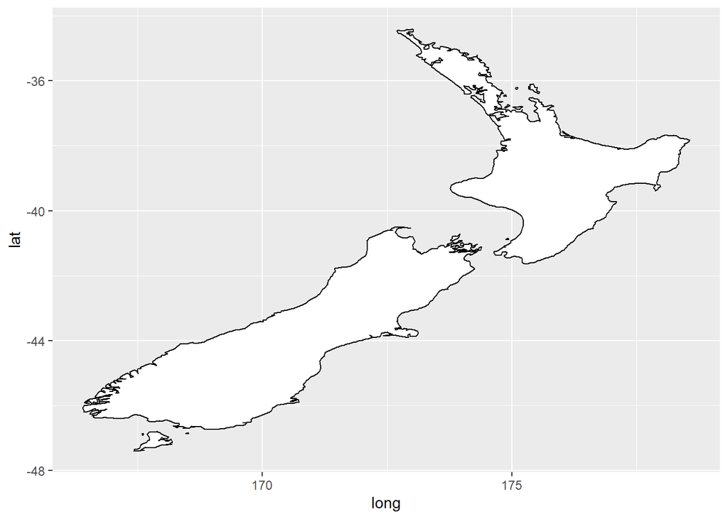

```r
nz <- map_data("nz")

ggplot(nz, aes(long, lat, group = group)) +
  geom_polygon(fill = "white", colour = "black")
```